# HOMEWORK 1

Sergio Martin & Amaranta Canova

2023-11-05

## BREAST CANCER PREDICTION

Breast cancer, a formidable adversary in the realm of healthcare, affects countless lives worldwide. It is the most common cancer among women, with a wide array of intricately interconnected features defining its progression and diagnosis. The quest to enhance the early detection and understanding of this disease has never been more critical. In this project, we embark on a data-driven exploration, harnessing the power of unsupervised learning techniques to unravel the hidden insights within the breast cancer dataset.

Our journey is structured into five distinct phases:

**1. Data Preprocessing:** Before we dive deep into the data, we’ll don our data detective hats to clean, prepare, and refine the dataset. This phase includes handling outliers and missing values (NA)

**2. Visualization Tools:** Visualizations are our compass, helping us navigate through the dataset’s rich landscape. We’ll use a range of visualization techniques to gain preliminary insights into the data, providing a visual map of its underlying structure, patterns, and relationships.

**3. Principal Component Analysis:** Armed with a better understanding of the data, we will venture into the realm of Principal Component Analysis (PCA). PCA is a dimensionality reduction technique that will allow us to highlight the most critical features that influence the variation within the dataset. It’s a crucial step in simplifying complex data while preserving essential information.

**4. Factor Analysis:** Factor analysis is another powerful tool in our toolkit. It will help us uncover latent variables or factors that underlie the observed features. By discerning the fundamental drivers of breast cancer characteristics, we aim to identify potentially overlooked patterns and correlations.

**5. Clustering Tools:** Finally, we’ll turn to clustering, where we let the data itself dictate its intrinsic groupings. Our goal is to identify clusters of patients with similar cancer characteristics, which could ultimately aid in more personalized treatment plans and prognostic predictions.

Through this project, we hope to contribute to the ongoing battle against breast cancer by unearthing the hidden connections and attributes within the data. Our ultimate objective is to empower healthcare professionals with improved diagnostic and treatment strategies, bringing us one step closer to a world with fewer uncertainties and brighter prospects for those affected by this formidable disease. Can we help with this study? Can we classify the data and find a relationship in which we can predict the patient’s tumor type?

The dataset contains 569 samples of malignant and benign tumor cells

- **ID Number**: A unique identification number for each sample.
- **Diagnosis (M or B)**: This is the target variable. “M” stands for malignant, indicating cancerous tumors, while “B” stands for benign, indicating non-cancerous tumors.
- **Radius (mean, se, worst)**: These features represent the mean, standard error, and worst (largest) radius of the cell nuclei. The radius is the average distance from the center of the nucleus to the points on its perimeter.
- **Texture (mean, se, worst)**: These features represent the mean, standard error, and worst texture, which describes the variation in grayscale intensities of the pixels in the cell nucleus.
- **Perimeter (mean, se, worst)**: These features represent the mean, standard error, and worst perimeter of the cell nuclei.
- **Area (mean, se, worst)**: These features represent the mean, standard error, and worst area of the cell nuclei.
- **Smoothness (mean, se, worst)**: These features represent the mean, standard error, and worst smoothness of the cell nuclei. Smoothness refers to the variation in radius lengths.
- **Compactness (mean, se, worst)**: These features represent the mean, standard error, and worst compactness, which is calculated as the perimeter^2 divided by the area.
- **Concavity (mean, se, worst)**: These features represent the mean, standard error, and worst concavity, which quantifies the level of concave portions in the contour of the cell nuclei.
- **Concave Points (mean, se, worst)**: These features represent the mean, standard error, and worst number of concave portions in the contour of the cell nuclei.
- **Symmetry (mean, se, worst)**: These features represent the mean, standard error, and worst symmetry of the cell nuclei.
- **Fractal Dimension (mean, se, worst)**: These features represent the mean, standard error, and worst fractal dimension, which quantifies the complexity of the cell nuclei’s perimeter.

Load Libraries

```r
library(VIM)
library(Quandl)
library(VIM)
library(lubridate)
library(GGally)
library(factoextra)
library(quantmod)
library(tidyverse)
library(ggplot2)
library(ggExtra)
library(plotly)
library(mice)
library(igraph)
library(countrycode)
library(mclust)
library(cluster)
library(corrplot)
library(gridExtra)
library(Seurat)
library(rgl)
library(ggstatsplot)
library(rstantools)
library(outliers)
library(psych)
```

## Load data

```r
Data = read.csv("breast-cancer - copia.csv")
```

```r
dim(Data)
```

```
[1] 569  32
```

```r
str(Data)
```

```
'data.frame':   569 obs. of  32 variables:
 $ id                     : int  842302 842517 84300903 84348301 84358402 843786 844359 84458202 844981 84501001 ...
 $ diagnosis              : chr  "M" "M" "M" "M" ...
 $ radius_mean            : num  18 20.6 19.7 11.4 20.3 ...
 $ texture_mean           : num  10.4 17.8 21.2 20.4 14.3 ...
 $ perimeter_mean         : num  122.8 132.9 130 77.6 135.1 ...
 $ area_mean              : num  1001 1326 1203 386 1297 ...
 $ smoothness_mean        : num  0.1184 0.0847 0.1096 0.1425 0.1003 ...
 $ compactness_mean       : num  0.2776 0.0786 0.1599 0.2839 0.1328 ...
 $ concavity_mean         : num  0.3001 0.0869 0.1974 0.2414 0.198 ...
 $ concave.points_mean    : num  0.1471 0.0702 0.1279 0.1052 0.1043 ...
 $ symmetry_mean          : num  0.242 0.181 0.207 0.26 0.181 ...
 $ fractal_dimension_mean : num  0.0787 0.0567 0.06 0.0974 0.0588 ...
 $ radius_se              : num  1.095 0.543 0.746 0.496 0.757 ...
 $ texture_se             : num  0.905 0.734 0.787 1.156 0.781 ...
```

[output cut: 18 more lines]

```r
head(Data)
```

|  | id | diagnosis | radius_mean | texture_mean | perimeter_mean | area_mean | smoothness_mean | compactness_mean | concavity_mean | concave.points_mean | symmetry_mean | fractal_dimension_mean | radius_se | texture_se | perimeter_se | area_se | smoothness_se | compactness_se | concavity_se | concave.points_se | symmetry_se | fractal_dimension_se | radius_worst | texture_worst | perimeter_worst | area_worst | smoothness_worst | compactness_worst | concavity_worst | … |
| --- | --- | --- | --- | --- | --- | --- | --- | --- | --- | --- | --- | --- | --- | --- | --- | --- | --- | --- | --- | --- | --- | --- | --- | --- | --- | --- | --- | --- | --- | --- |
| 1 | 842302 | M | 17.99 | 10.38 | 122.80 | 1001.0 | 0.11840 | 0.27760 | 0.3001 | 0.14710 | 0.2419 | 0.07871 | 1.0950 | 0.9053 | 8.589 | 153.40 | 0.006399 | 0.04904 | 0.05373 | 0.01587 | 0.03003 | 0.006193 | 25.38 | 17.33 | 184.60 | 2019.0 | 0.1622 | 0.6656 | 0.7119 | … |
| 2 | 842517 | M | 20.57 | 17.77 | 132.90 | 1326.0 | 0.08474 | 0.07864 | 0.0869 | 0.07017 | 0.1812 | 0.05667 | 0.5435 | 0.7339 | 3.398 | 74.08 | 0.005225 | 0.01308 | 0.01860 | 0.01340 | 0.01389 | 0.003532 | 24.99 | 23.41 | 158.80 | 1956.0 | 0.1238 | 0.1866 | 0.2416 | … |
| 3 | 84300903 | M | 19.69 | 21.25 | 130.00 | 1203.0 | 0.10960 | 0.15990 | 0.1974 | 0.12790 | 0.2069 | 0.05999 | 0.7456 | 0.7869 | 4.585 | 94.03 | 0.006150 | 0.04006 | 0.03832 | 0.02058 | 0.02250 | 0.004571 | 23.57 | 25.53 | 152.50 | 1709.0 | 0.1444 | 0.4245 | 0.4504 | … |
| 4 | 84348301 | M | 11.42 | 20.38 | 77.58 | 386.1 | 0.14250 | 0.28390 | 0.2414 | 0.10520 | 0.2597 | 0.09744 | 0.4956 | 1.1560 | 3.445 | 27.23 | 0.009110 | 0.07458 | 0.05661 | 0.01867 | 0.05963 | 0.009208 | 14.91 | 26.50 | 98.87 | 567.7 | 0.2098 | 0.8663 | 0.6869 | … |
| 5 | 84358402 | M | 20.29 | 14.34 | 135.10 | 1297.0 | 0.10030 | 0.13280 | 0.1980 | 0.10430 | 0.1809 | 0.05883 | 0.7572 | 0.7813 | 5.438 | 94.44 | 0.011490 | 0.02461 | 0.05688 | 0.01885 | 0.01756 | 0.005115 | 22.54 | 16.67 | 152.20 | 1575.0 | 0.1374 | 0.2050 | 0.4000 | … |
| 6 | 843786 | M | 12.45 | 15.70 | 82.57 | 477.1 | 0.12780 | 0.17000 | 0.1578 | NA | 0.2087 | 0.07613 | 0.3345 | 0.8902 | 2.217 | 27.19 | 0.007510 | 0.03345 | 0.03672 | 0.01137 | 0.02165 | 0.005082 | 15.47 | 23.75 | 103.40 | 741.6 | 0.1791 | 0.5249 | 0.5355 | … |

```r
tail(Data)
```

|  | id | diagnosis | radius_mean | texture_mean | perimeter_mean | area_mean | smoothness_mean | compactness_mean | concavity_mean | concave.points_mean | symmetry_mean | fractal_dimension_mean | radius_se | texture_se | perimeter_se | area_se | smoothness_se | compactness_se | concavity_se | concave.points_se | symmetry_se | fractal_dimension_se | radius_worst | texture_worst | perimeter_worst | area_worst | smoothness_worst | compactness_worst | concavity_worst | … |
| --- | --- | --- | --- | --- | --- | --- | --- | --- | --- | --- | --- | --- | --- | --- | --- | --- | --- | --- | --- | --- | --- | --- | --- | --- | --- | --- | --- | --- | --- | --- |
| 564 | 926125 | M | 20.92 | 25.09 | 143.00 | 1347.0 | 0.10990 | 0.22360 | 0.31740 | 0.14740 | 0.2149 | 0.06879 | 0.9622 | 1.026 | 8.758 | 118.80 | 0.006399 | 0.04310 | 0.07845 | 0.02624 | 0.02057 | 0.006213 | 24.290 | 29.41 | 179.10 | 1819.0 | 0.14070 | 0.41860 | 0.6599 | … |
| 565 | 926424 | M | 21.56 | 22.39 | 142.00 | 1479.0 | 0.11100 | 0.11590 | 0.24390 | 0.13890 | 0.1726 | 0.05623 | 1.1760 | 1.256 | 7.673 | 158.70 | 0.010300 | 0.02891 | 0.05198 | 0.02454 | 0.01114 | 0.004239 | 25.450 | 26.40 | 166.10 | 2027.0 | 0.14100 | 0.21130 | 0.4107 | … |
| 566 | 926682 | M | 20.13 | 28.25 | 131.20 | 1261.0 | 0.09780 | 0.10340 | 0.14400 | 0.09791 | 0.1752 | 0.05533 | 0.7655 | 2.463 | 5.203 | 99.04 | 0.005769 | 0.02423 | 0.03950 | 0.01678 | 0.01898 | 0.002498 | 23.690 | 38.25 | 155.00 | 1731.0 | 0.11660 | 0.19220 | 0.3215 | … |
| 567 | 926954 | M | 16.60 | 28.08 | 108.30 | 858.1 | 0.08455 | 0.10230 | 0.09251 | 0.05302 | 0.1590 | 0.05648 | 0.4564 | 1.075 | 3.425 | 48.55 | 0.005903 | 0.03731 | 0.04730 | 0.01557 | 0.01318 | 0.003892 | 18.980 | 34.12 | 126.70 | 1124.0 | 0.11390 | 0.30940 | 0.3403 | … |
| 568 | 927241 | M | 20.60 | 29.33 | 140.10 | 1265.0 | 0.11780 | 0.27700 | 0.35140 | 0.15200 | 0.2397 | 0.07016 | 0.7260 | 1.595 | 5.772 | 86.22 | 0.006522 | 0.06158 | 0.07117 | 0.01664 | 0.02324 | 0.006185 | 25.740 | 39.42 | 184.60 | 1821.0 | 0.16500 | 0.86810 | 0.9387 | … |
| 569 | 92751 | B | 7.76 | 24.54 | 47.92 | 181.0 | 0.05263 | 0.04362 | 0.00000 | 0.00000 | 0.1587 | 0.05884 | 0.3857 | 1.428 | 2.548 | 19.15 | 0.007189 | 0.00466 | 0.00000 | 0.00000 | 0.02676 | 0.002783 | 9.456 | 30.37 | 59.16 | 268.6 | 0.08996 | 0.06444 | 0.0000 | … |

```r
summary(Data)
```

```
       id             diagnosis          radius_mean      texture_mean   perimeter_mean     area_mean
 Min.   :     8670   Length:569         Min.   : 6.981   Min.   : 9.71   Min.   : 43.79   Min.   : 143.5
 1st Qu.:   869218   Class :character   1st Qu.:11.700   1st Qu.:16.17   1st Qu.: 75.17   1st Qu.: 420.3
 Median :   906024   Mode  :character   Median :13.370   Median :18.84   Median : 86.24   Median : 551.1
 Mean   : 30371831                      Mean   :14.127   Mean   :19.29   Mean   : 91.97   Mean   : 654.9
 3rd Qu.:  8813129                      3rd Qu.:15.780   3rd Qu.:21.80   3rd Qu.:104.10   3rd Qu.: 782.7
 Max.   :911320502                      Max.   :28.110   Max.   :39.28   Max.   :188.50   Max.   :2501.0

 smoothness_mean   compactness_mean  concavity_mean    concave.points_mean symmetry_mean    fractal_dimension_mean
 Min.   :0.05263   Min.   :0.01938   Min.   :0.00000   Min.   :0.00000     Min.   :0.1060   Min.   :0.04996
 1st Qu.:0.08637   1st Qu.:0.06492   1st Qu.:0.02956   1st Qu.:0.02031     1st Qu.:0.1619   1st Qu.:0.05770
 Median :0.09587   Median :0.09263   Median :0.06154   Median :0.03345     Median :0.1792   Median :0.06154
 Mean   :0.09636   Mean   :0.10434   Mean   :0.08880   Mean   :0.04886     Mean   :0.1812   Mean   :0.06280
 3rd Qu.:0.10530   3rd Qu.:0.13040   3rd Qu.:0.13070   3rd Qu.:0.07373     3rd Qu.:0.1957   3rd Qu.:0.06612
 Max.   :0.16340   Max.   :0.34540   Max.   :0.42680   Max.   :0.20120     Max.   :0.3040   Max.   :0.09744
                                                       NA's   :1
   radius_se        texture_se      perimeter_se       area_se        smoothness_se      compactness_se
 Min.   :0.1115   Min.   :0.3602   Min.   : 0.757   Min.   :  6.802   Min.   :0.001713   Min.   :0.002252
 1st Qu.:0.2324   1st Qu.:0.8339   1st Qu.: 1.606   1st Qu.: 17.850   1st Qu.:0.005169   1st Qu.:0.013080
 Median :0.3240   Median :1.1080   Median : 2.287   Median : 24.530   Median :0.006380   Median :0.020450
 Mean   :0.4052   Mean   :1.2169   Mean   : 2.866   Mean   : 40.337   Mean   :0.007041   Mean   :0.025478
 3rd Qu.:0.4798   3rd Qu.:1.4740   3rd Qu.: 3.357   3rd Qu.: 45.190   3rd Qu.:0.008146   3rd Qu.:0.032450
 Max.   :2.8730   Max.   :4.8850   Max.   :21.980   Max.   :542.200   Max.   :0.031130   Max.   :0.135400
 NA's   :1
  concavity_se     concave.points_se   symmetry_se       fractal_dimension_se  radius_worst   texture_worst
 Min.   :0.00000   Min.   :0.000000   Min.   :0.007882   Min.   :0.0008948    Min.   : 7.93   Min.   :12.02
 1st Qu.:0.01509   1st Qu.:0.007638   1st Qu.:0.015160   1st Qu.:0.0022480    1st Qu.:13.01   1st Qu.:21.08
 Median :0.02589   Median :0.010930   Median :0.018730   Median :0.0031870    Median :14.97   Median :25.41
 Mean   :0.03189   Mean   :0.011796   Mean   :0.020542   Mean   :0.0037949    Mean   :16.27   Mean   :25.68
 3rd Qu.:0.04205   3rd Qu.:0.014710   3rd Qu.:0.023480   3rd Qu.:0.0045580    3rd Qu.:18.79   3rd Qu.:29.72
 Max.   :0.39600   Max.   :0.052790   Max.   :0.078950   Max.   :0.0298400    Max.   :36.04   Max.   :49.54

 perimeter_worst    area_worst     smoothness_worst  compactness_worst concavity_worst  concave.points_worst
 Min.   : 50.41   Min.   : 185.2   Min.   :0.07117   Min.   :0.02729   Min.   :0.0000   Min.   :0.00000
 1st Qu.: 84.11   1st Qu.: 515.3   1st Qu.:0.11660   1st Qu.:0.14720   1st Qu.:0.1145   1st Qu.:0.06493
 Median : 97.66   Median : 686.5   Median :0.13130   Median :0.21190   Median :0.2267   Median :0.09993
 Mean   :107.26   Mean   : 880.6   Mean   :0.13237   Mean   :0.25427   Mean   :0.2722   Mean   :0.11461
 3rd Qu.:125.40   3rd Qu.:1084.0   3rd Qu.:0.14600   3rd Qu.:0.33910   3rd Qu.:0.3829   3rd Qu.:0.16140
 Max.   :251.20   Max.   :4254.0   Max.   :0.22260   Max.   :1.05800   Max.   :1.2520   Max.   :0.29100

 symmetry_worst   fractal_dimension_worst
 Min.   :0.1565   Min.   :0.05504
 1st Qu.:0.2504   1st Qu.:0.07146
 Median :0.2822   Median :0.08004
 Mean   :0.2901   Mean   :0.08395
 3rd Qu.:0.3179   3rd Qu.:0.09208
 Max.   :0.6638   Max.   :0.20750
```

## Data Preproccesing

We are not interested on the patient_id as that is a random number assigned to each of it, so we remove that variable

```r
X = Data[,-1]
```

### Missing Values

```r
colSums(is.na(X))
```

```
              diagnosis             radius_mean            texture_mean          perimeter_mean               area_mean
                      0                       0                       0                       0                       0
        smoothness_mean        compactness_mean          concavity_mean     concave.points_mean           symmetry_mean
                      0                       0                       0                       1                       0
 fractal_dimension_mean               radius_se              texture_se            perimeter_se                 area_se
                      0                       1                       0                       0                       0
          smoothness_se          compactness_se            concavity_se       concave.points_se             symmetry_se
                      0                       0                       0                       0                       0
   fractal_dimension_se            radius_worst           texture_worst         perimeter_worst              area_worst
                      0                       0                       0                       0                       0
       smoothness_worst       compactness_worst         concavity_worst    concave.points_worst          symmetry_worst
                      0                       0                       0                       0                       0
fractal_dimension_worst
                      0
```

```
 Variables sorted by number of missings:
```

| Variable | Count |
| --- | --- |
| concave.points_mean | 0.001757469 |
| radius_se | 0.001757469 |
| diagnosis | 0.000000000 |
| radius_mean | 0.000000000 |
| texture_mean | 0.000000000 |
| perimeter_mean | 0.000000000 |
| area_mean | 0.000000000 |
| smoothness_mean | 0.000000000 |
| compactness_mean | 0.000000000 |
| concavity_mean | 0.000000000 |

[output cut: 21 more lines]

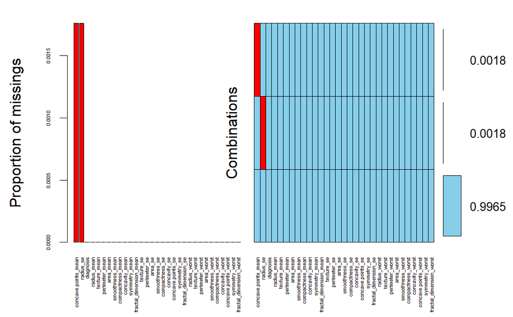

```r
#With that we already see that there are not missing values, but let's check making a plot
aggr(X, numbers = T, sortVars = T, labels = names(X), cex.axis = .4, gap = 0.5, label = c("Missing data", "Patern"))
```

We have two missing values, one on the variable concave.points_mean and other on radius_se

As they are only two rows with 1 variable with an NA value , replace them by an estimate using random forest

```r
# Comlete NA values
imp = mice(X, method = "rf", m = 5)
# this method makes estimation of your Na values using random forest
X = complete(imp)
#Check that we don't have NA values now
colSums(is.na(X))
```

```
              diagnosis             radius_mean            texture_mean          perimeter_mean               area_mean
                      0                       0                       0                       0                       0
        smoothness_mean        compactness_mean          concavity_mean     concave.points_mean           symmetry_mean
                      0                       0                       0                       0                       0
 fractal_dimension_mean               radius_se              texture_se            perimeter_se                 area_se
                      0                       0                       0                       0                       0
          smoothness_se          compactness_se            concavity_se       concave.points_se             symmetry_se
                      0                       0                       0                       0                       0
   fractal_dimension_se            radius_worst           texture_worst         perimeter_worst              area_worst
                      0                       0                       0                       0                       0
       smoothness_worst       compactness_worst         concavity_worst    concave.points_worst          symmetry_worst
                      0                       0                       0                       0                       0
fractal_dimension_worst
                      0
```

### Outliers

Make boxplot with each variable in order to identify the outliers

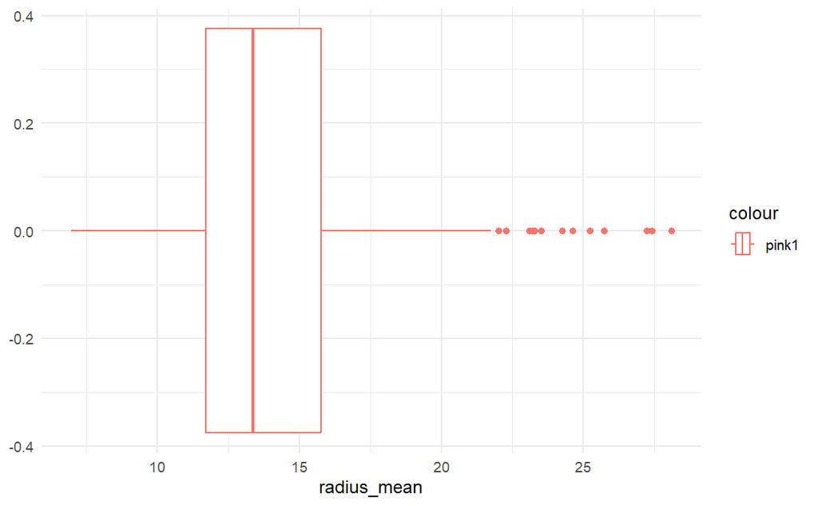

```r
par(mfrow=c(3,1))

ggplot(X) +aes(x =radius_mean, color = "pink1", leyend = F) +geom_boxplot() + theme_minimal()
```

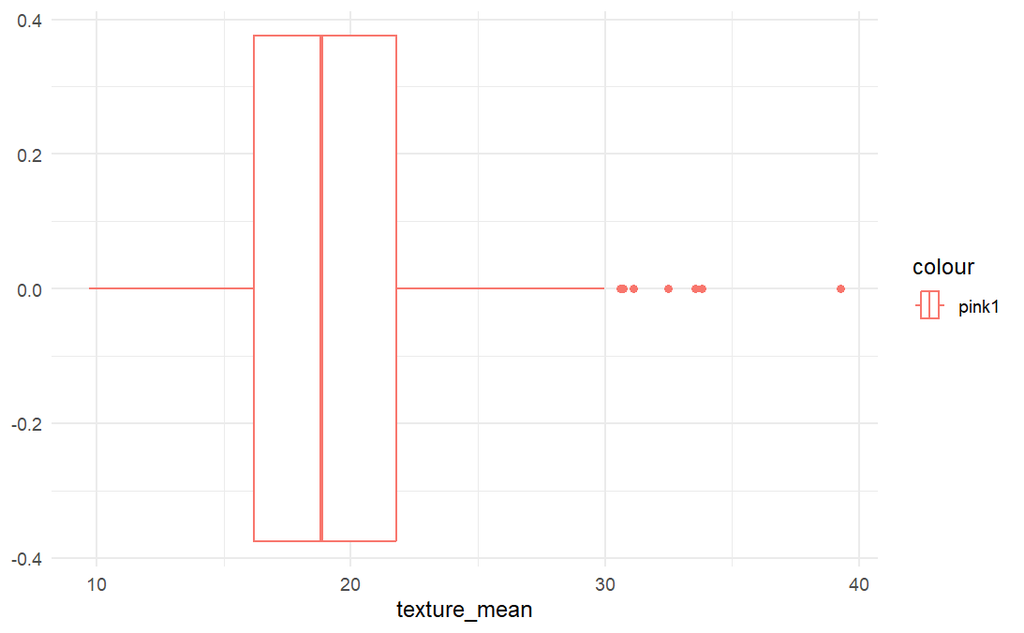

```r
ggplot(X) +aes(x =texture_mean, color = "pink1", leyend = F) +geom_boxplot() + theme_minimal()
```

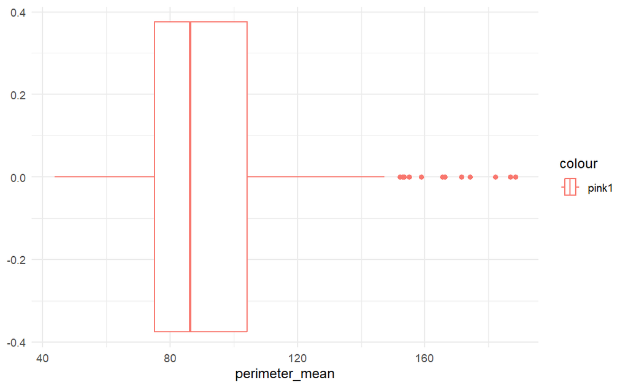

```r
ggplot(X) +aes(x =perimeter_mean, color = "pink1", leyend = F) +geom_boxplot() + theme_minimal()
```

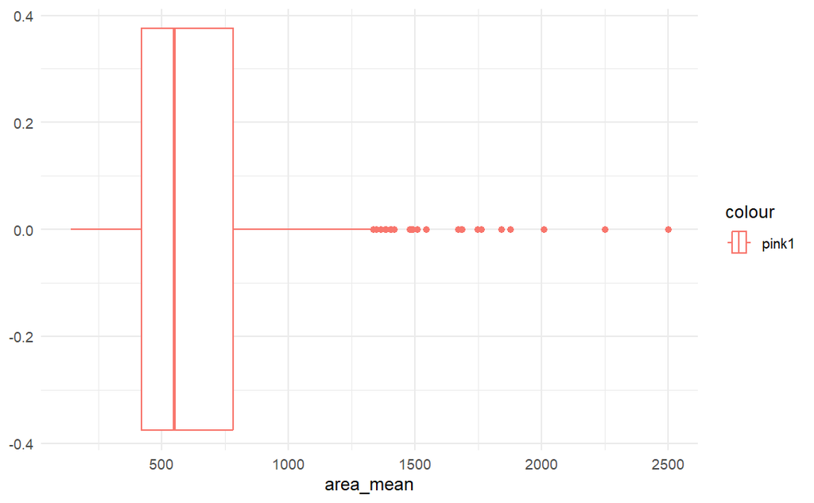

```r
ggplot(X) +aes(x =area_mean, color = "pink1", leyend = F) +geom_boxplot() + theme_minimal()
```

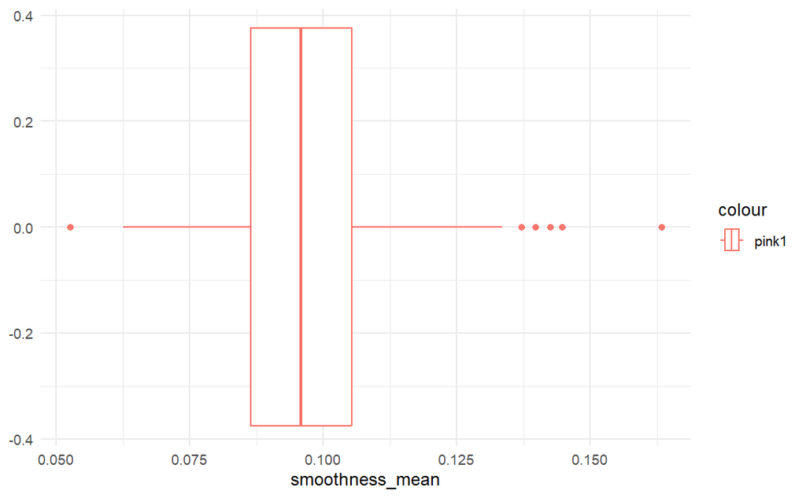

```r
ggplot(X) +aes(x =smoothness_mean, color = "pink1", leyend = F) +geom_boxplot() + theme_minimal()
```

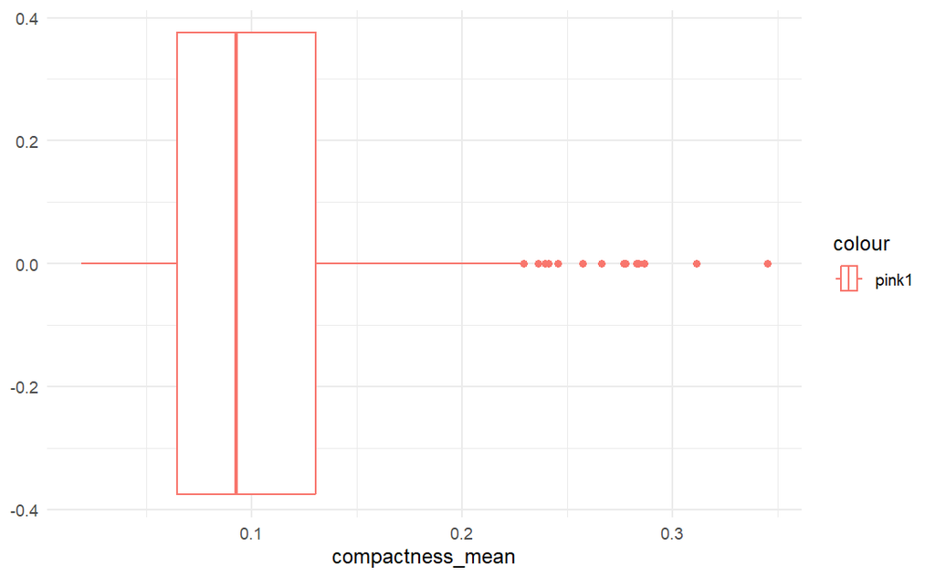

```r
ggplot(X) +aes(x =compactness_mean, color = "pink1", leyend = F) +geom_boxplot() + theme_minimal()
```

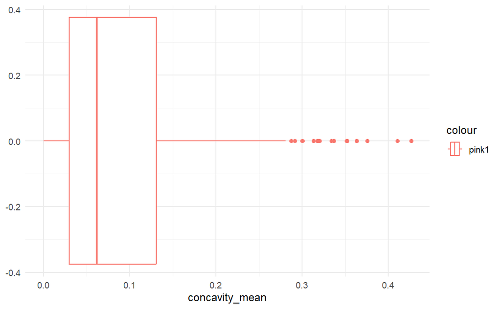

```r
ggplot(X) +aes(x =concavity_mean, color = "pink1", leyend = F) +geom_boxplot() + theme_minimal()
```

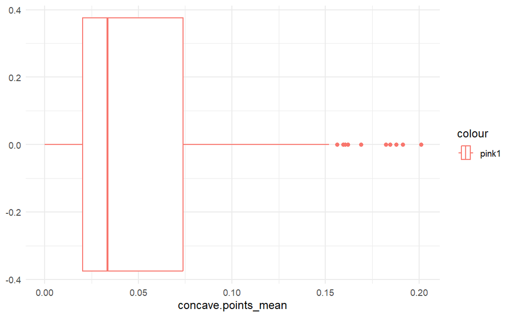

```r
ggplot(X) +aes(x =concave.points_mean, color = "pink1", leyend = F) +geom_boxplot() + theme_minimal()
```

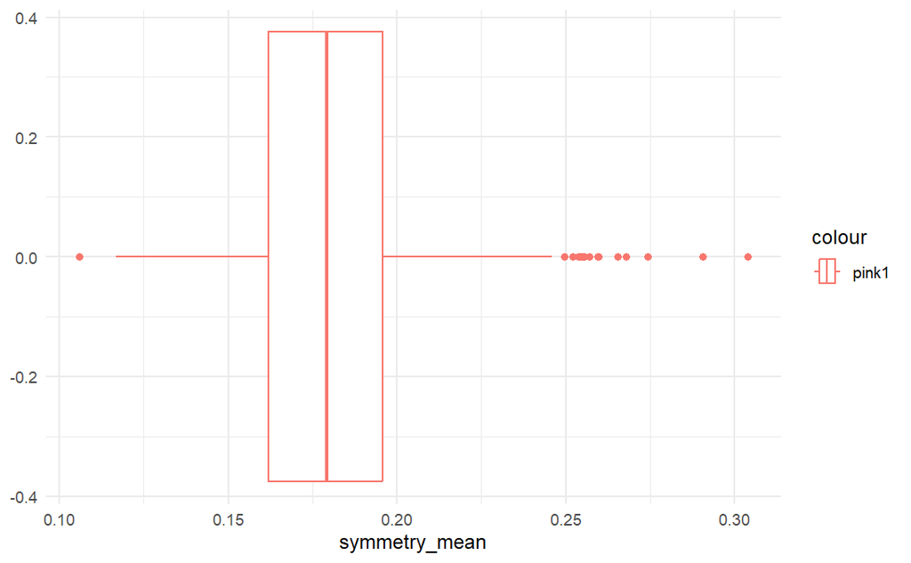

```r
ggplot(X) +aes(x =symmetry_mean, color = "pink1", leyend = F) +geom_boxplot() + theme_minimal()
```

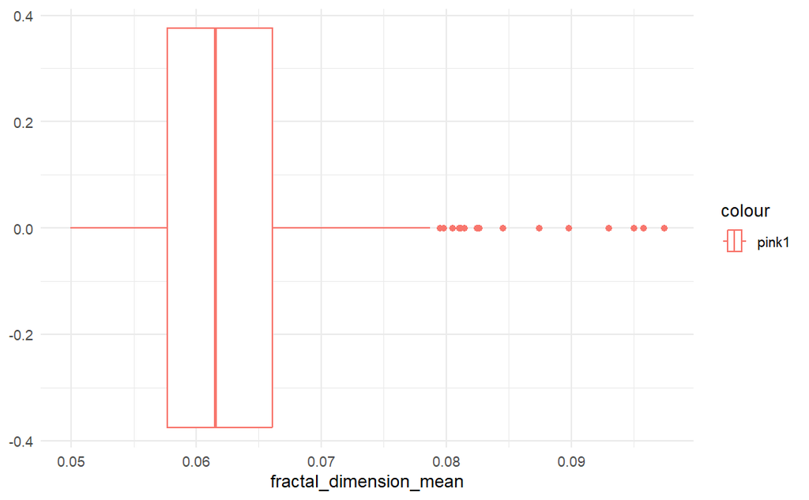

```r
ggplot(X) +aes(x =fractal_dimension_mean, color = "pink1", leyend = F) +geom_boxplot() + theme_minimal()
```

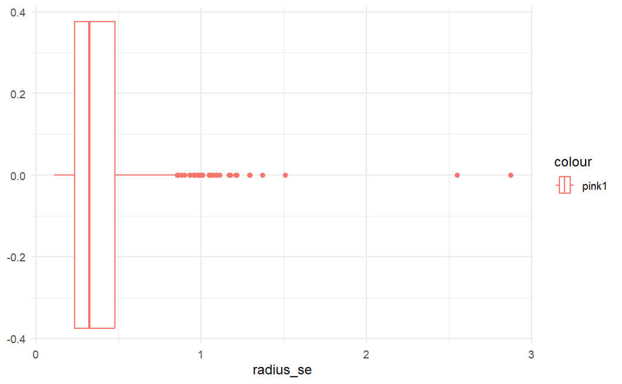

```r
ggplot(X) +aes(x =radius_se, color = "pink1", leyend = F) +geom_boxplot() + theme_minimal()
```

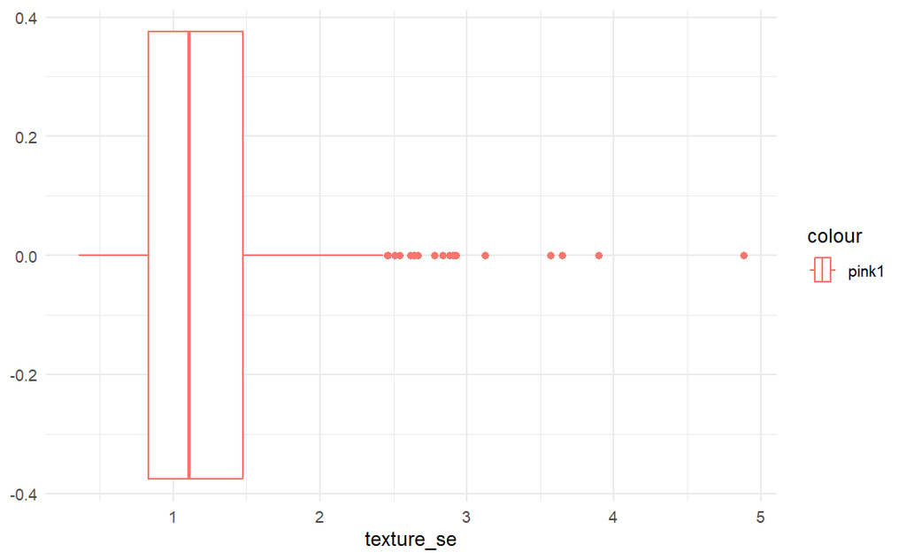

```r
ggplot(X) +aes(x =texture_se, color = "pink1", leyend = F) +geom_boxplot() + theme_minimal()
```

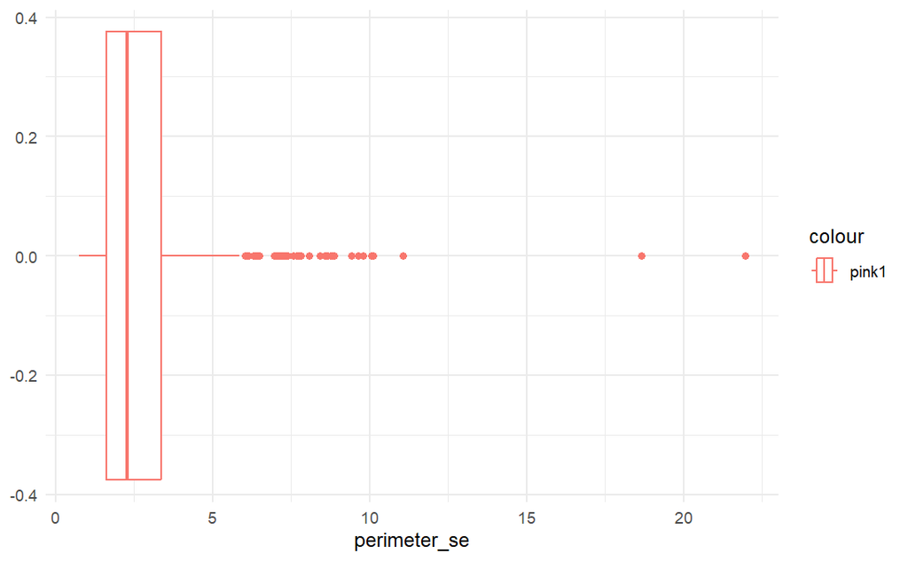

```r
ggplot(X) +aes(x =perimeter_se, color = "pink1", leyend = F) +geom_boxplot() + theme_minimal()
```

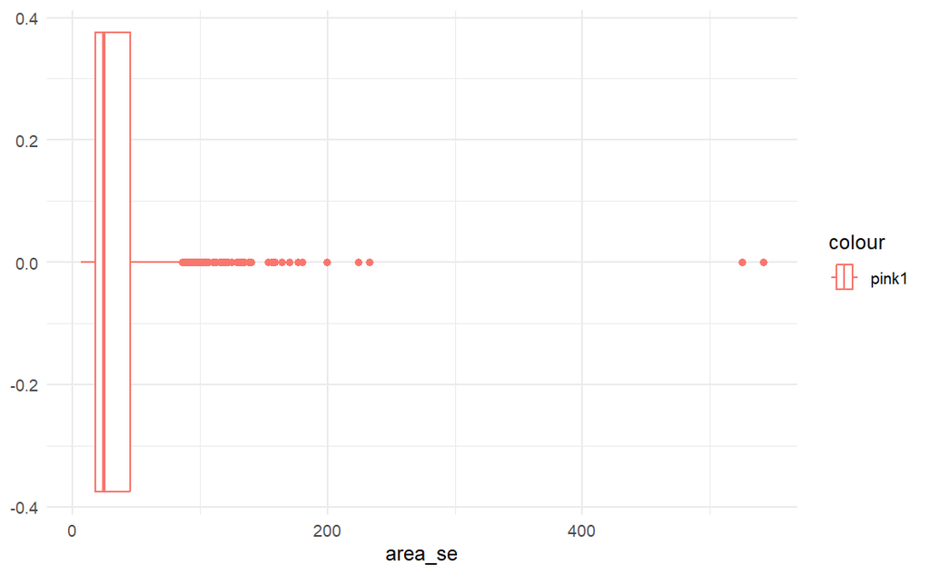

```r
ggplot(X) +aes(x =area_se, color = "pink1", leyend = F) +geom_boxplot() + theme_minimal()
```

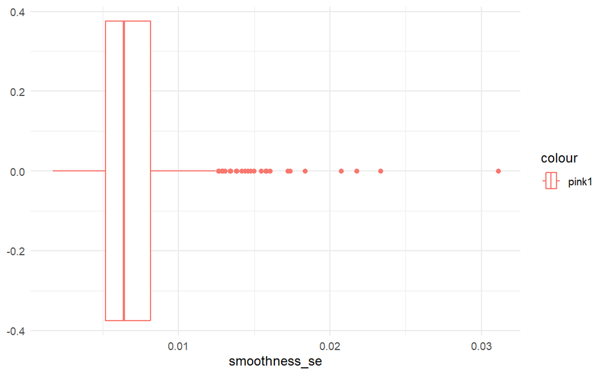

```r
ggplot(X) +aes(x =smoothness_se, color = "pink1", leyend = F) +geom_boxplot() + theme_minimal()
```

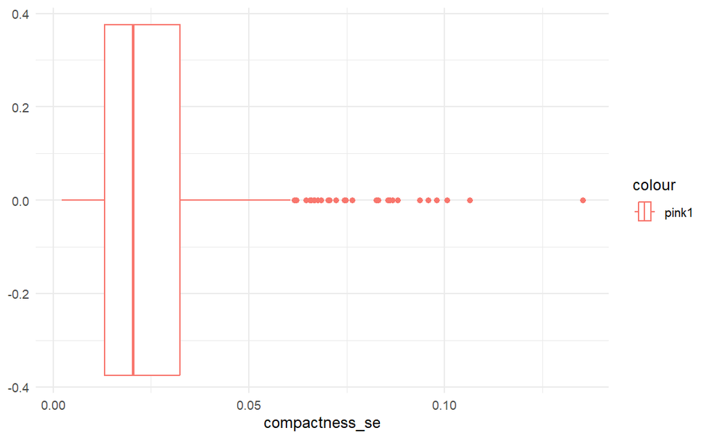

```r
ggplot(X) +aes(x =compactness_se, color = "pink1", leyend = F) +geom_boxplot() + theme_minimal()
```

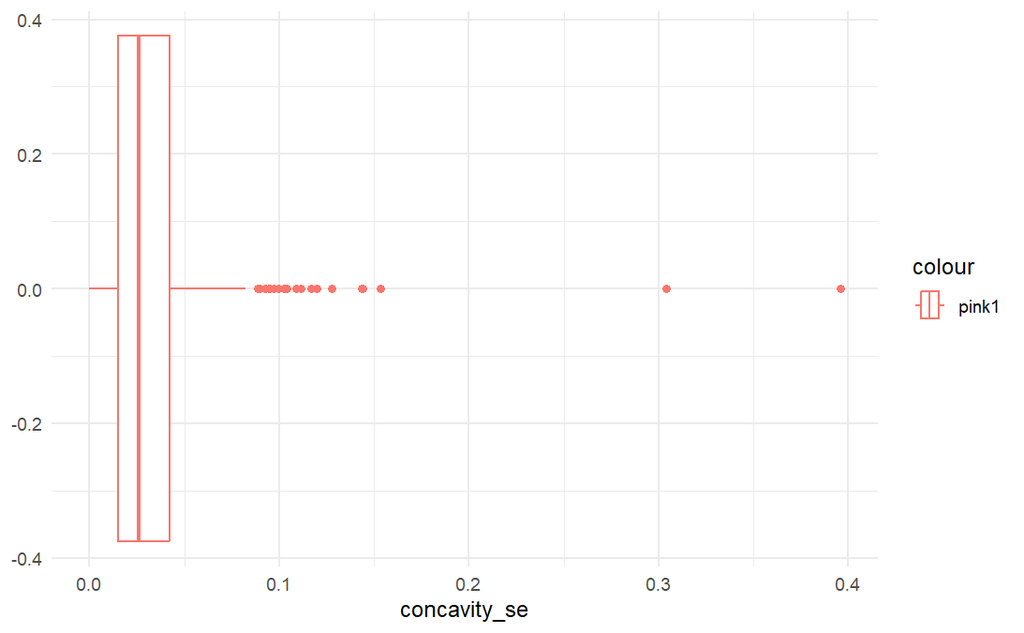

```r
ggplot(X) +aes(x =concavity_se, color = "pink1", leyend = F) +geom_boxplot() + theme_minimal()
```

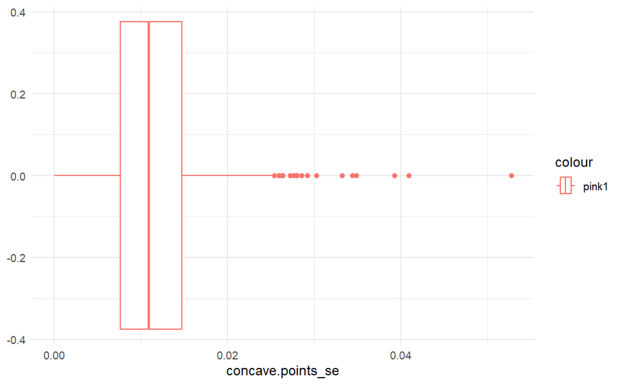

```r
ggplot(X) +aes(x =concave.points_se, color = "pink1", leyend = F) +geom_boxplot() + theme_minimal()
```

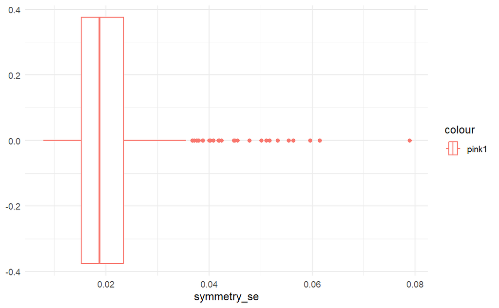

```r
ggplot(X) +aes(x =symmetry_se, color = "pink1", leyend = F) +geom_boxplot() + theme_minimal()
```

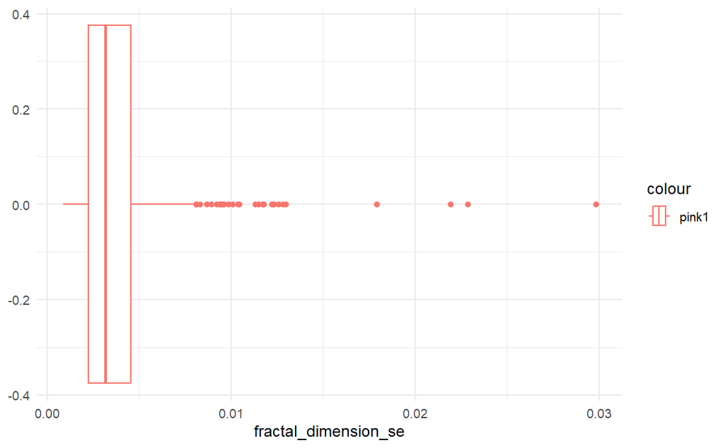

```r
ggplot(X) +aes(x =fractal_dimension_se, color = "pink1", leyend = F) +geom_boxplot() + theme_minimal()
```

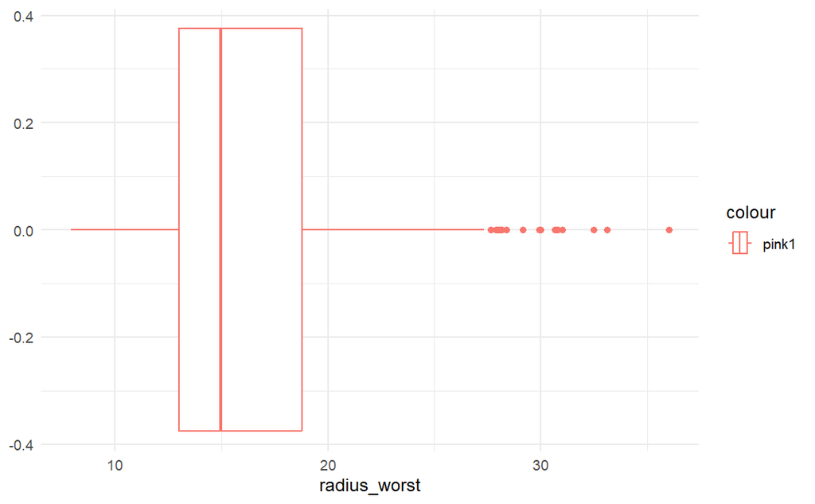

```r
ggplot(X) +aes(x =radius_worst, color = "pink1", leyend = F) +geom_boxplot() + theme_minimal()
```

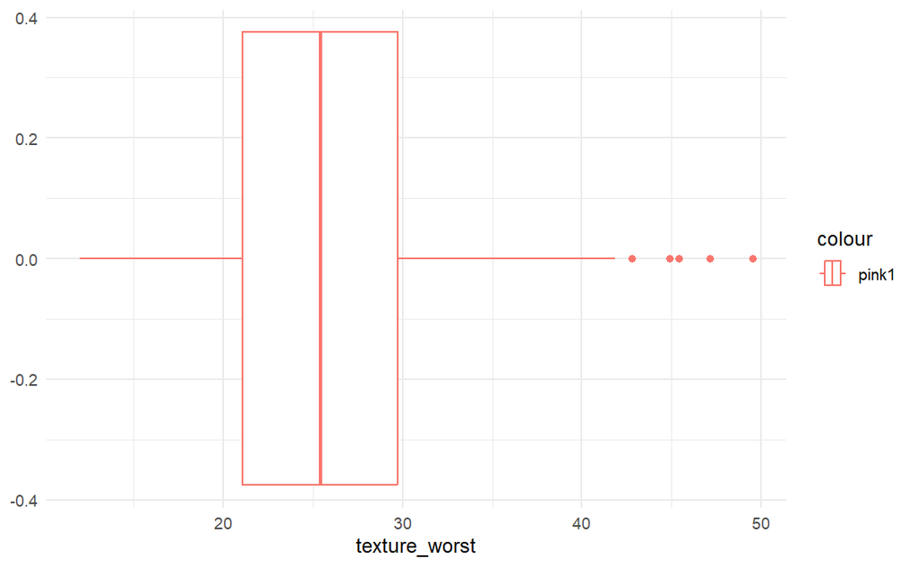

```r
ggplot(X) +aes(x =texture_worst, color = "pink1", leyend = F) +geom_boxplot() + theme_minimal()
```

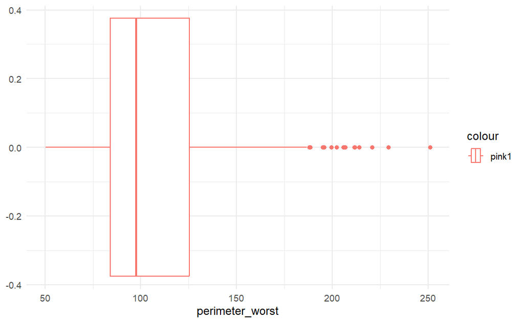

```r
ggplot(X) +aes(x =perimeter_worst, color = "pink1", leyend = F) +geom_boxplot() + theme_minimal()
```

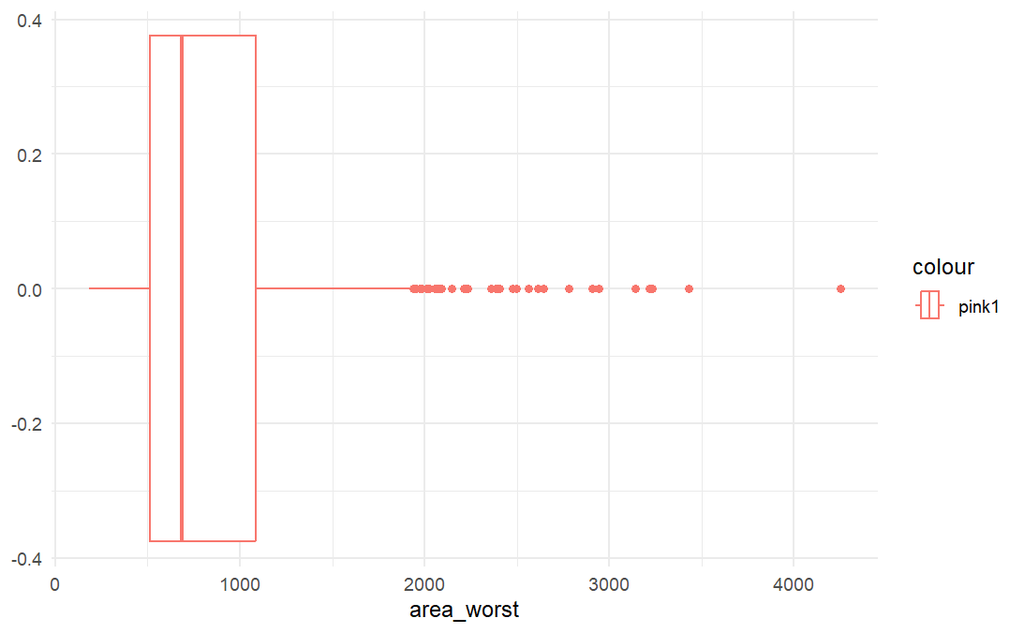

```r
ggplot(X) +aes(x =area_worst, color = "pink1", leyend = F) +geom_boxplot() + theme_minimal()
```

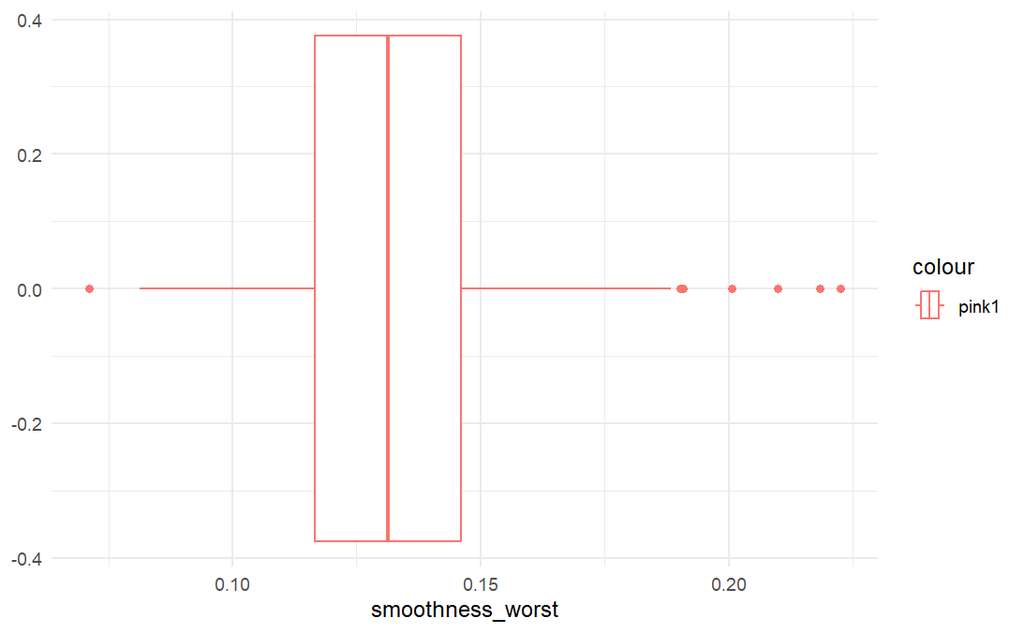

```r
ggplot(X) +aes(x =smoothness_worst, color = "pink1", leyend = F) +geom_boxplot() + theme_minimal()
```

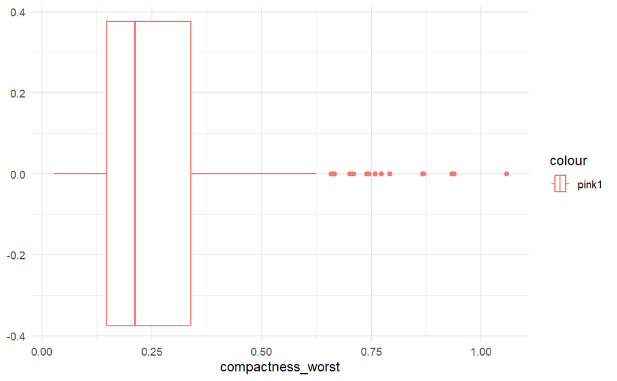

```r
ggplot(X) +aes(x =compactness_worst, color = "pink1", leyend = F) +geom_boxplot() + theme_minimal()
```

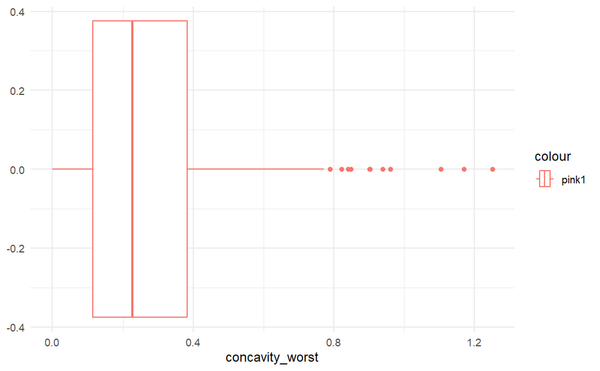

```r
ggplot(X) +aes(x =concavity_worst, color = "pink1", leyend = F) +geom_boxplot() + theme_minimal()
```

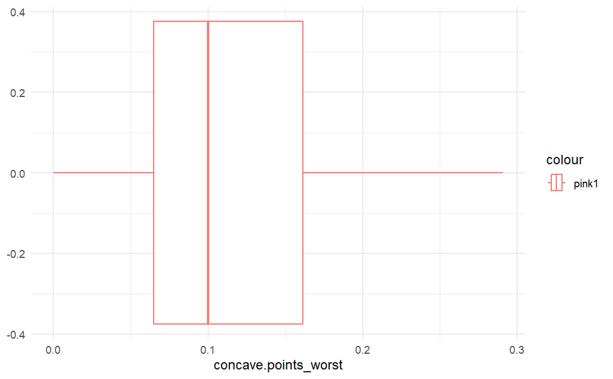

```r
ggplot(X) +aes(x =concave.points_worst, color = "pink1", leyend = F) +geom_boxplot() + theme_minimal()
```

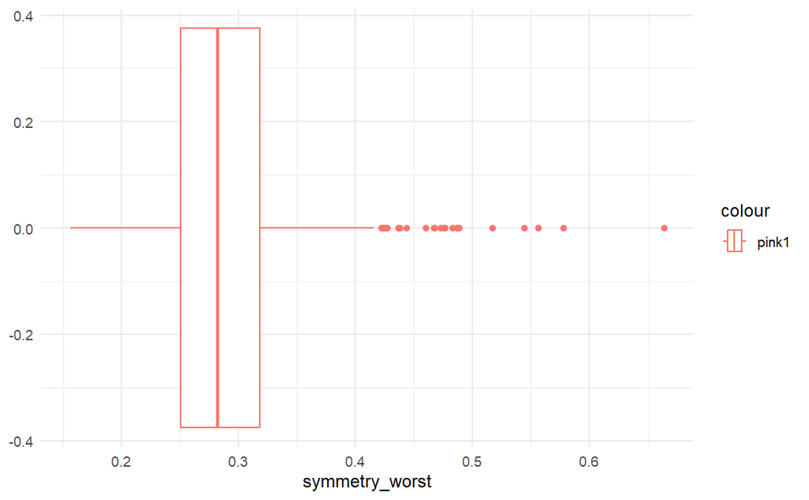

```r
ggplot(X) +aes(x =symmetry_worst, color = "pink1", leyend = F) +geom_boxplot() + theme_minimal()
```

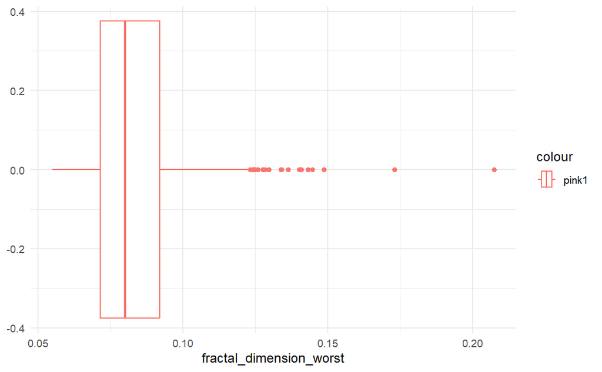

```r
ggplot(X) +aes(x =fractal_dimension_worst, color = "pink1", leyend = F) +geom_boxplot() + theme_minimal()
```

```r
NA
NA
NA
NA
NA
```

Most of them have some outliers. Remove them for having the data set cleaned

**REMOVE OUTLIERS:** By analyzing the previous boxplots, we can see from which values in each variable there begin to be considerable outliers. For that reason, we are going to remove them

```r
# Remove rows with outliers
# Filter the data to remove outliers based on your criteria
X <- subset(
  X,
  !(radius_se > 2 |
    radius_mean > 25|
    texture_se > 3 |
    texture_mean > 32 |
    perimeter_se > 7.5 |
    perimeter_mean > 160 |
    smoothness_mean > 0.140 |
    area_mean > 1500 |
    concave.points_mean > 0.17 |
    compactness_mean > 0.25 |
    symmetry_mean > 0.25 |
    concavity_mean > 0.3 |
    radius_se > 1 |
    fractal_dimension_mean > 0.08 |
    texture_se > 2.75 |
    perimeter_se > 8 |
    area_se > 190 |
    smoothness_se > 0.015 |
    compactness_se > 0.55 |
    concavity_se > 0.1 |
    concave.points_se > 0.03 |
    symmetry_se > 0.04 |
    fractal_dimension_se > 0.01 |
    radius_worst > 30 |
    perimeter_worst > 200 |
    area_worst > 2500 |
    smoothness_worst > 0.20 |
    compactness_worst > 0.75 |
    concavity_worst > 1 |
    symmetry_worst > 0.5 |
    fractal_dimension_worst > 0.14
  )
)
```